# Decision Trees and Random Forests

Please reference the video lecture for an overview of Decision Trees and Random Forests. This is just a reference notebook for the lecture video's code.

## Growing a Decision Tree

You may need to install the rpart library. you can find a lot more information about this library [here](http://www.mayo.edu/hsr/techrpt/61.pdf).

```r
#install.packages('rpart)
```

```r
library(rpart)
```

We can then use the rpart() function to build a decision tree model:

**rpart(formula, data=, method=,control=) where**

- the formula is in the format: outcome ~ predictor1+predictor2+predictor3+ect.
- data= specifies the data frame
- method= "class" for a classification tree
- "anova" for a regression tree
- control= optional parameters for controlling tree growth.
  - For example, control=rpart.control(minsplit=30, cp=0.001) requires that the minimum number of observations in a node be 30 before attempting a split and that a split must decrease the overall lack of fit by a factor of 0.001 (cost complexity factor) before being attempted.

## Sample Data

We'll use the kyphosis data frame which has 81 rows and 4 columns. representing data on children who have had corrective spinal surgery. It has the following columns:

- Kyphosis-a factor with levels absent present indicating if a kyphosis (a type of deformation) was present after the operation.
- Age-in months
- Number-the number of vertebrae involved
- Start-the number of the first (topmost) vertebra operated on.

Let's check out the structure:

```r
str(kyphosis)
```

```
'data.frame':	81 obs. of  4 variables:
 $ Kyphosis: Factor w/ 2 levels "absent","present": 1 1 2 1 1 1 1 1 1 2 ...
 $ Age     : int  71 158 128 2 1 1 61 37 113 59 ...
 $ Number  : int  3 3 4 5 4 2 2 3 2 6 ...
 $ Start   : int  5 14 5 1 15 16 17 16 16 12 ...
```

```r
head(kyphosis)
```

|  | Kyphosis | Age | Number | Start |
| --- | --- | --- | --- | --- |
| 1 | absent | 71 | 3 | 5 |
| 2 | absent | 158 | 3 | 14 |
| 3 | present | 128 | 4 | 5 |
| 4 | absent | 2 | 5 | 1 |
| 5 | absent | 1 | 4 | 15 |
| 6 | absent | 1 | 2 | 16 |

```r
tree <- rpart(Kyphosis ~ . , method='class', data= kyphosis)
```

## Examining Results of the Tree Model

There are lots of functions you can use to examine your tree model:

| **printcp(***fit***)** | display cp table |
| --- | --- |
| **plotcp(***fit***)** | plot cross-validation results |
| **rsq.rpart(***fit***)** | plot approximate R-squared and relative error for different splits (2 plots). labels are only appropriate for the "anova" method. |
| **print(***fit***)** | print results |
| **summary(***fit***)** | detailed results including surrogate splits |
| **plot(***fit***)** | plot decision tree |
| **text(***fit***)** | label the decision tree plot |
| **post(***fit*, **file=)** | create postscript plot of decision tree |

Let's see a few of them:

```r
printcp(tree)
```

```
Classification tree:
rpart(formula = Kyphosis ~ ., data = kyphosis, method = "class")

Variables actually used in tree construction:
[1] Age   Start

Root node error: 17/81 = 0.20988

n= 81

        CP nsplit rel error xerror    xstd
1 0.176471      0   1.00000 1.0000 0.21559
2 0.019608      1   0.82353 1.0588 0.22010
3 0.010000      4   0.76471 1.0588 0.22010
```

## Tree Visualization

There are some built-in visualization capabilities from the table above, but they aren't very good looking:

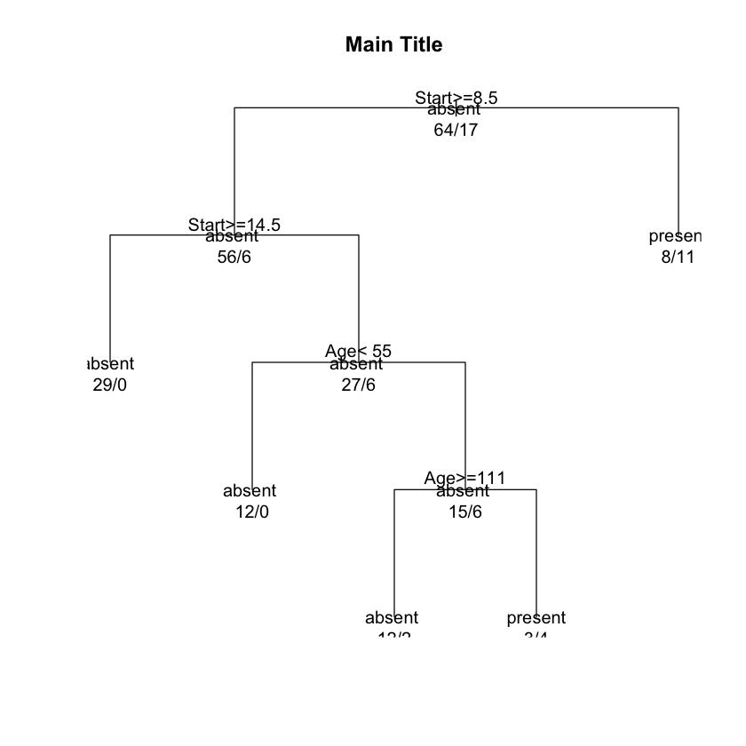

```r
plot(tree, uniform=TRUE, main="Main Title")
text(tree, use.n=TRUE, all=TRUE)
```

The rpart.plot library package makes these visualizations much better.

```r
#install.packages('rpart.plot')
```

```r
library(rpart.plot)
```

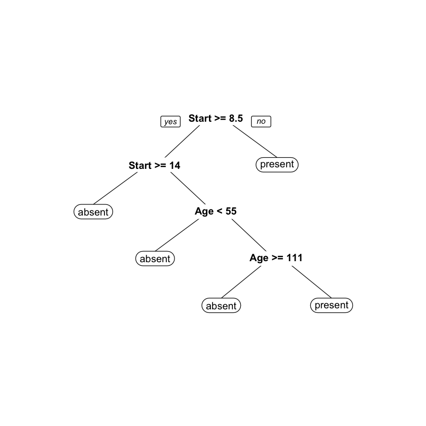

```r
prp(tree)
```

# Random Forests

Random forests improve predictive accuracy by generating a large number of bootstrapped trees (based on random samples of variables), classifying a case using each tree in this new "forest", and deciding a final predicted outcome by combining the results across all of the trees (an average in regression, a majority vote in classification).

We can use the randomForest library to create and build out a Random Forest:

```r
# Random Forest prediction of Kyphosis data
library(randomForest)
```

```r
model <- randomForest(Kyphosis ~ .,   data=kyphosis)
```

```r
print(model) # view results
```

```
Call:
 randomForest(formula = Kyphosis ~ ., data = kyphosis)
               Type of random forest: classification
                     Number of trees: 500
No. of variables tried at each split: 1

        OOB estimate of  error rate: 19.75%
Confusion matrix:
        absent present class.error
absent      60       4   0.0625000
present     12       5   0.7058824
```

```r
importance(model) # importance of each predictor
```

|  | MeanDecreaseGini |
| --- | --- |
| Age | 8.739632 |
| Number | 5.497958 |
| Start | 9.998735 |

## Conclusion

You should be beginning to feel very comfortable with the syntax for training a model on data. The key is to just understand the background of the algorithm being used and know what library to install and use for the specific algorithm being used.